# Stephanie’s Housing Request

**Week 1 Analysis**

## Background

Stephanie[^1] is a student that will be starting school at BYU-Idaho next semester. Suppose she sent you the following email.

“Hi. My name is Stephanie. I would like to learn about what housing options I have for living at BYU-Idaho next semester. It will be my first semester there, so I would like to find something that is close to campus and around $300 a month in rent. I’m not too picky on roomates, but I would like somewhere that has a lot of people around so I can get to know as many people as possible. Thanks in advance!”

Write your response to Stephanie below. Use the “Rent” dataset, good statistical analysis, and clear writing to make some well supported suggestions to her about apartments that meet her stated criterions. You are free to use other criterion that you think she might find more meaningful as well.

## Response

Dear Stephanie, It seems that the criteria you’re looking for is something that’s cheap and close to campus, and having a lot of people around is a big bonus.

I included a scatterplot of walking distance and the price for each apartment, and you’ll notice that the cheapest options and the apartments with the smallest walking distances are on the bottom left of the graph. The three that stand out and that I would recommend looking into first are Normandy Apartments, Bayside Manor, and Birch Plaza.

```r
# Code to get you started, be sure to use a subset of Rent instead of Rent in this code though.
datatable(Rent, options=list(lengthMenu = c(3,10,30)), extensions="Responsive")
```

|  | Apartment | Gender | Address | Phone | Price | PrivateRoomPrice | Capacity | ParkingStalls | Deposit | UtilityDeposit | FloorPlans | Website | Latitude | Longitude | MilesToCampus | WalkingMinutes | Description |
| --- | --- | --- | --- | --- | --- | --- | --- | --- | --- | --- | --- | --- | --- | --- | --- | --- | --- |
| 1 | ABBY LANE MANOR | F | 437 S 4TH W | (208) 359-3687 | 1035 | 1060 | 42 | 38 | 100 | 0 | 3 | www.abbylaneapartments.com | 43.8169418 | -111.7952062 | 0.745647284 | 16 | We are a small women's complex offering private rooms and quaint living. Many students enjoy our advantages enough that they stay with us until graduation. We are sure you would like staying with us! … |
| 2 | ABODE DUPLEX | M | 224 E 2ND S | (912) 399-1107 | 980 | 980 | 6 | 3 | 100 | 0 | 1 | sites.google.com/site/robertspencerbrown/abodehouse | 43.8218153 | -111.7771495 | 0.186411821 | 4 | This cozy little apartment is located only one block from campus. There are a lot of freebies for the price. All utilities are included, there is a free-to-use, in-apartment washer and dryer, free WiF… |
| 3 | ABRI APARTMENTS - MEN | M | 220 E 1ST S | 2084177223 | 1420 | 1445 | 138 | 216 | 150 | 0 | 3 | www.liveabri.com | 43.8239342 | -111.7773062 | 0.310686368 | 8 | 24 hour special $100 off! Look no further than the Abri, Rexburg's newest student housing community. Currently leasing women's spots for fall '17, &amp; men's for winter '18. From upscale, modern fini… |
| 4 | ABRI APARTMENTS - WOMEN | F | 220 E 1ST S | (208) 417-7223 | 1445 | 1495 | 150 | 216 | 150 | 0 | 3 | www.liveabri.com | 43.8239342 | -111.7773062 | 0.310686368 | 8 | $100 OFF SPECIAL! Look no further than the Abri, Rexburg's newest student housing community. Currently leasing women's spots for fall '17, &amp; men's for winter '18. From upscale, modern finishes, to… |
| 5 | ALBION APARTMENT | F | 231 W 2ND S | (801) 856-0732 | 1062.5 | 1150 | 5 | 4 | 100 | 0 | 3 |  | 43.8218385 | -111.7906463 | 0.186411821 | 4 | Cute, newly painted basement apartment across the street from Porter Park and 1.5 blocks from the Hart building. Utilities and Internet are free. Washer and Dryer included in the Apartment. There are … |
| 6 | ALEXANDER APARTMENT | F | 276 W 3RD S | 208-995-8543 | 972.5 | 1115 | 22 | 18 | 100 | 0 | 10 | www.alexanderapartments.wordpress.com | 43.8197811 | -111.7918951 | 0.434960916 | 8 | We are also signing for Fall and Winter 2017. Get $25 off per semester for signing 2 consecutive semesters. No application fee or parking fee and get $40 in quarters for laundry each semester. |
| 7 | ALLDREDGE HOUSE | F | 243 S 1ST E | 208-206-4697 | 1045 | 1095 | 8 | 8 | 150 | 0 | 3 |  | 43.82073 | -111.780478 | 0.186411821 | 5 | Hurry quick! Come make ALLDREDGE HOUSE your home away from home! Located directly across the street from the Clarke and Kirkham Buildings and only a few blocks away from down town. Great ward with the… |
| 8 | ALLEN RIDGE APARTMENTS | M | 57 S CENTER ST | (801) 864-1708 | 890 | 890 | 17 | 9 | 100 | 0 | 1 | allenridge.blogspot.com | 43.824663 | -111.7835934 | 0.310686368 | 6 | The best kept housing secret at BYU-Idaho. Small complex (only 17 tenants), but large living areas and rooms. Private, but in the best location in town - central to campus, shopping, and great activit… |
| 9 | ALLEN'S SUNRISE VILLAGE - MEN | M | 48 W 2ND S | 356-3995 | 1000 | 1075 | 138 | 133 | 100 | 0 | 3 | www.sunrisevillageapts.com | 43.821866 | -111.7852097 | 0.062137274 | 1 | Allen's Sunrise Village offers housing for both men and women! We are well-known for our friendliness,low prices,great location,fantastically reliable OPTIX internet,friendly residents and amazing man… |
| 10 | ALLEN'S SUNRISE VILLAGE - WOMEN | F | 48 W 2ND S | 208-356-3995 | 1000 | 1075 | 144 | 133 | 100 | 0 | 3 | www.sunrisevillageapts.com | 43.82186 | -111.785197 | 0.062137274 | 1 | We offer housing for both men and women! We are well-known for our friendliness, new modern remodel, low prices, great location, our fantastically reliable OPTIX internet and amazing managers. You'll … |

[output cut: 112 more lines]

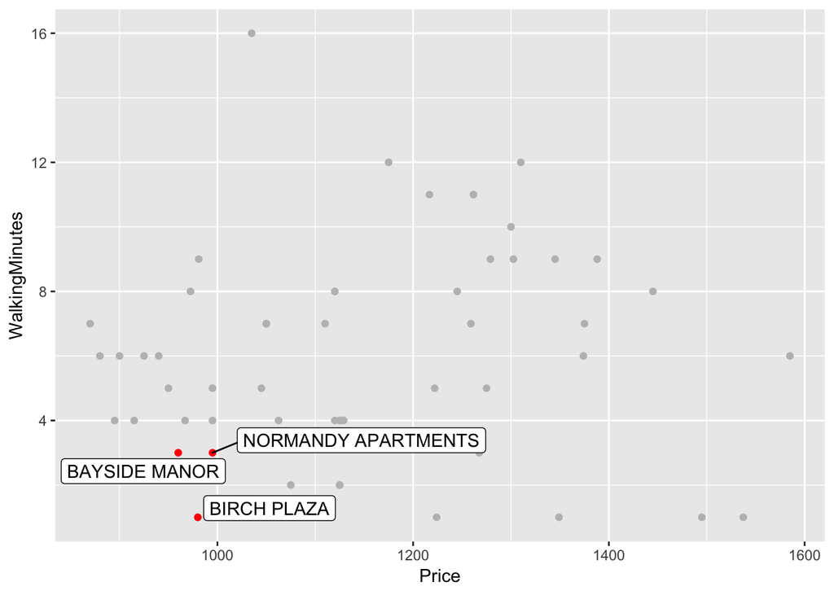

```r
y_limits <- c(1500, NA)

RentF <- filter(Rent, Gender == "F")
ggplot(RentF, aes(x=Price, y=WalkingMinutes, label = Apartment)) +
  geom_point(color = ifelse(RentF$Price < 1000 & RentF$WalkingMinutes < 4, "red", "gray")) +
  geom_label_repel(data = subset(RentF, Price < 1000 & WalkingMinutes < 4,
                  direction     = "x",
                  segment.size  = 0.01,
                  ylim = y_limits,
                  segment.color = "red"
                ))
```

[^1]: Note that Stephanie is a fictional character who is based on real experiences of many faculty and staff here at BYU-Idaho.